# Investigating a Chain of Interacting Beads

$ \hspace{1in}\displaystyle \dot{\boldsymbol{\mathrm r}} = \dfrac{\sum \boldsymbol{\mathrm F}}{b} $

where the sum of the forces is:

$ \hspace{1in}\displaystyle \sum\boldsymbol{\mathrm F} = \boldsymbol{\mathrm F} _{\mathrm{random}} + \boldsymbol{\mathrm F}_{\mathrm{FENE}} + \boldsymbol{\mathrm F}_{\mathrm{excluded \, volume}} $

where $k_{\mathrm{excluded \, volume}} = 0 \,\rightarrow\, \boldsymbol{\mathrm F}_{\mathrm{excluded \, volume}} = 0$.

$ \hspace{1in}\displaystyle \boldsymbol{\mathrm F}_{\mathrm{FENE}}\left(\boldsymbol{\mathrm r}\right) = \frac{3k_{\mathrm{B}}T}{l_{\mathrm{k}}} \left[ \frac{\boldsymbol{\mathrm r}/L_{\mathrm{s}}}{1-{\left(\boldsymbol{\mathrm r}/L_{\mathrm{s}}\right)^2}} \right] $

where $l_{\mathrm{k}}$ is the Kuhn length and $L_{\mathrm{s}}$ is the maximum spring length. The thermal energy is set to unity.

```python
import numpy as np
import matplotlib.pyplot as plt
import os
from scipy.optimize import curve_fit

N = 1500001
nbeads = 100
Δt = .0001

t = []     # time array
tt = 0
for i in range(N):
    t.append(tt)
    tt += Δt
```

## Importing and averaging

```python
file = os.path.join('simulated_data', 'k_ev=0', 'D_parameters', f'ave_rg_ree_n{nbeads}.dat')
#file = os.path.join('simulated_data', f'ave_rg_ree_n{nbeads}.dat')
Rg_all = np.loadtxt(file, skiprows=0)[:, 0]
Ree_all = np.loadtxt(file, skiprows=0)[:, 1]

Rg_all_i = []
Ree_all_i = []
for i in range(N):
    Rg_all_i.append([])
    Ree_all_i.append([])

for i in range(int(len(Rg_all)/N)):
    for j in range(N):
        Rg_all_i[j].append(Rg_all[j + i*N])
        Ree_all_i[j].append(Ree_all[j + i*N])

# 1 trial
Rg_ave, Ree_ave = Rg_all.tolist(), Ree_all.tolist()

# ▼▼ multiple trials ▼▼
#Rg_ave = []
#Ree_ave = []
#for i in range(N):
 #   Rg_ave.append(np.mean(Rg_all_i[i]))
 #   Ree_ave.append(np.mean(Ree_all_i[i]))
```

## Curve fitting to find relaxation time

```python
NoT = int(len(Rg_all)/N)
print(f"The number of trials is {NoT} and the number of iterations per trial is {N}.")
```

```
The number of trials is 1 and the number of iterations per trial is 1500001.
```

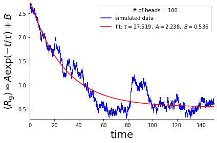

```
   τ = 27.518617404202789345 ± 0.018519718575761648
   A = 2.238440033729880430 ± 0.000737386922752253
   B = 0.536195414741181930 ± 0.000285680481958708
```

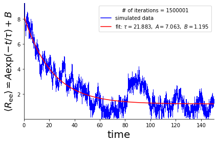

```
   τ = 21.882790955213334172 ± 0.018323546507787117
   A = 7.062756535925154289 ± 0.003242196394251298
   B = 1.194869380369930401 ± 0.000948508421121995
```

```python
#from scipy.special import expit
#Ree_ave=expit(Ree_ave)     # supress warning
#Rg_ave=expit(Rg_ave)       # supress warning


t = np.array(t)     # maybe call it t_arr (or not who cares)
def exp_decay(t, τ, A, B):
    return A*np.exp(-t/τ) + B


p0 = (0.1, 1, 0)     # p0 = (τ0, A0, B0)
###### radius of gyration plots #####
plt.plot(t[0], Rg_ave[0], 'b', label='simulated data')  # "averaged simulated data"
plt.plot(t, Rg_ave, 'b,')#, label='averaged simulated data')
popt, pcov = curve_fit(exp_decay, t, Rg_ave, p0)
plt.plot(t, exp_decay(t, *popt), 'r-', label=r'fit: $\tau=%5.3f,~A=%5.3f,~B=%.3f$' % tuple(popt))
plt.xlabel(r"time", fontsize=20)
plt.ylabel(r"$\left\langle{R_\mathrm{g}}\right\rangle \,\backsimeq\, A\exp\left(-t/\tau\right)+B$", fontsize=18)

plt.legend(title=f"# of beads = {nbeads}") # handles=legend_elements
plt.xlim(min(t), max(t))
plt.ylim(min(Rg_ave), max(Rg_ave))

plt.gca().spines['right'].set_visible(False)
plt.gca().spines['top'].set_visible(False)
plt.tight_layout()
#plt.savefig("rg_vs_t.pdf")
plt.show()

print('   τ =', '%0.18f' % popt[0], '±', "%.18f" % pcov[0,0]**0.5) #2ND HALF IS FIT UNCERTAINTY
print('   A =', "%0.18f" % popt[1], '±', "%.18f" % pcov[1,1]**0.5)
print('   B =', "%0.18f" % popt[2], '±', "%.18f" % pcov[2,2]**0.5)
#####################################


##### end to end distance plots #####
plt.plot(t[0], Ree_ave[0], 'b', label='simulated data')  # "averaged simulated data"
plt.plot(t, Ree_ave, 'b,')#, label='averaged simulated data')
popt, pcov = curve_fit(exp_decay, t, Ree_ave, p0)
plt.plot(t, exp_decay(t, *popt), 'r-', label=r'fit: $\tau=%5.3f,~A=%5.3f,~B=%.3f$' % tuple(popt))
plt.xlabel(r"time", fontsize=20)
plt.ylabel(r"$\left\langle{R_\mathrm{ee}}\right\rangle \,\backsimeq\, A\exp\left(-t/\tau\right)+B$", fontsize=18)

plt.legend(title=f"# of iterations = {N}") # handles=legend_elements
plt.xlim(min(t), max(t))
plt.ylim(min(Ree_ave), max(Ree_ave))

plt.gca().spines['right'].set_visible(False)
plt.gca().spines['top'].set_visible(False)
plt.tight_layout()
#plt.savefig("rg_vs_t.pdf")
plt.show()

print('   τ =', '%0.18f' % popt[0], '±', "%.18f" % pcov[0,0]**0.5) #2ND HALF IS FIT UNCERTAINTY
print('   A =', "%0.18f" % popt[1], '±', "%.18f" % pcov[1,1]**0.5)
print('   B =', "%0.18f" % popt[2], '±', "%.18f" % pcov[2,2]**0.5)
```

## Checking length dependencies

### Data entry

#### Parameters D

- $k_{\mathrm{ev}} = 0$
- $N = 1,\!500,\!001$
- $\Delta t = 0.0001$

Note that for the `nbeads = 125` simulation, the chain does not reach relaxation; however, it the fit does appear to be accurate. But I actually don't think it is 😕. Which is why I am ignoring `125`, saving `100` to a `pt2` directory, and rerunning `100`. $100$ beads is the maximum that this simulation can handle with this $N$ and $\Delta t$.

```python
>>> mm = (2, 5, 10, 15, 20, 30, 40, 50, 60, 75, 100)#, 125)

# p0 = (0.1, 1, 0) turned on:
>>> τg = (0.088580258090960151, 0.668504964791880152, 0.031231604149272087, 0.117617934007477762, 0.702774209581846554,
          1.007633115730365736, 2.321961206871950623, 7.812281986854997307, 9.13733001264371580, 18.841332936074469018,
          27.518617404202789345)#, 48.715319789632594905)
>>> τee = (0.088592333465821654, 0.420749601312219279, 0.026857081101279420, 0.122805660690007923, 0.818634908038646025,
           1.036324822012720581, 1.948235189029468239, 8.453584009602710836, 7.798159819875366772, 16.897650398066438981,
           21.882790955213334172)#, 42.802257225994850387)
"""
# p0 turned off
>>> τg = (2.600210117792457698, 0.668504964791880152, 0.479933190417691502, 0.117812596984877699, 0.703409615982306446,
          1.007309915681367185, 2.322093984059212968, 7.812578544517621459, 9.137481312128622690, 18.840555255645774935,
          27.518764053357617883)#, 48.715079249074356937)
>>> τee = (2.600210117792457698, 0.420749601312219279, 0.58025749947096838, 0.123187267350313573, 0.817751228723137435,
           1.036834224759285439, 1.948233657383970918, 8.452926379493813869, 7.797324121504962235, 16.897910132494324387,
           21.882801147781869133)#, 42.802709736849202216)
"""
τg_err = ()
τee_err = ()
```

Eliminating the transient parts of $\left\langle{\!R_\mathrm{g}\!}\right\rangle$ and $\big\langle{\!R_\mathrm{ee}\!}\big\rangle$. Check both the final half as well as final third.

```
for m in mm:
    file = os.path.join('simulated_data', 'k_ev=0', 'D_parameters', f'ave_rg_ree_n{m}.dat')
    #file = os.path.join('simulated_data', f'ave_rg_ree_n{nbeads}.dat')
    Rg_all = np.loadtxt(file, skiprows=0)[:, 0]
    Ree_all = np.loadtxt(file, skiprows=0)[:, 1]

    Rg_all_i = []
    Ree_all_i = []
    for i in range(N):
        Rg_all_i.append([])
        Ree_all_i.append([])

    for i in range(int(len(Rg_all)/N)):
        for j in range(N):
            Rg_all_i[j].append(Rg_all[j + i*N])
            Ree_all_i[j].append(Ree_all[j + i*N])

    # 1 trial
    Rg_ave, Ree_ave = Rg_all.tolist(), Ree_all.tolist()

    # multiple trials
    # ... left out for clutterness, see 'importing and averaging' for this part of code ...

    del Rg_ave[0:int(2*len(Rg_ave)/3)]
    del Ree_ave[0:int(2*len(Ree_ave)/3)]

    Rg_ave_mean = Rg_ave_mean + (np.mean(Rg_ave),)
    Ree_ave_mean = Ree_ave_mean + (np.mean(Ree_ave),)
```

```python
# two thirds cut-off
"""
Rg_ave_mean = (0.07921786753817055, 0.15057729185983318, 0.20902138229615227, 0.2573833381975815, 0.30614490587222287,
               0.3979263395139394, 0.4421741140122233, 0.49255437618259734, 0.5654270314645351, 0.5102541545195519,
               0.5568367747058757)
Ree_ave_mean = (0.1584357350763411, 0.3122465837971835, 0.4485308751117977, 0.5367854707831147, 0.6852854210841368,
                0.9509229897795856, 0.9990228884016049, 1.1855281435834488, 1.320139292392346, 1.2561496053617007,
                1.0345178154292776)
"""

# half cut-off
Rg_ave_mean = (0.07895618271556007, 0.14986486461251836, 0.21149616233046573, 0.26034250861026714, 0.3017130488766601,
               0.3823558711122843, 0.42394831886094353, 0.5318548546637942, 0.5289390851884113, 0.5342386170356787,
               0.6358291607903418)
Ree_ave_mean = (0.15791236543112014, 0.3105929766703069, 0.45283628658693825, 0.5560532795788296, 0.6741804643656221,
                0.8823423367098437, 0.9415483506233866, 1.2921610209871588, 1.1668971877772978, 1.2760441487252736,
                1.4088927261879929)

# l = (2, 5, 10, 15, 20, 30, 40, 50, 60, 75, 100)
```

### Check Scaling

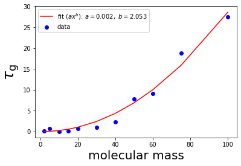

```
   a = 0.002245738713339380 ± 0.001704853381556289
   b = 2.052688245482727769 ± 0.170050726680836539
```

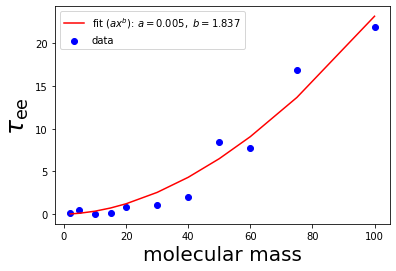

```
   a = 0.004914184456708002 ± 0.004737570939619960
   b = 1.836929127175338516 ± 0.217185162295612438
```

```python
def power(x, a, b):
    return a*x**b

#mm = mm[:-1]; τg = τg[:-1]; τee = τee[:-1];# Rg_ave_mean = Rg_ave_mean[:-1]; Ree_ave_mean = Ree_ave_mean[:-1]

# Rg
plt.scatter(mm, τg, color='blue', label='data')

popt, pcov = curve_fit(power, mm, τg)
plt.plot(mm, power(mm, *popt), 'r-', label=r'fit $\left(ax^b\right)$: $a=%5.3f,~b=%.3f$' % tuple(popt))
plt.legend()

plt.xlabel(r"molecular mass", fontsize=20)
plt.ylabel(r"$\tau_{\mathrm{g}}$", fontsize=25)
#plt.savefig("plots/τg_v_mm_scatter_fit.pdf", bbox_inches='tight')
plt.show()
print('   a =', '%0.18f' % popt[0], '±', "%.18f" % pcov[0,0]**0.5) #THE 2ND HALF IS CODE FOR CALCULATING FIT UNCERTAINTY
print('   b =', "%0.18f" % popt[1], '±', "%.18f" % pcov[1,1]**0.5)


# Ree
plt.scatter(mm, τee, color='blue', label='data')

popt, pcov = curve_fit(power, mm, τee)
plt.plot(mm, power(mm, *popt), 'r-', label=r'fit $\left(ax^b\right)$: $a=%5.3f,~b=%.3f$' % tuple(popt))
plt.legend()

plt.xlabel(r"molecular mass", fontsize=20)
plt.ylabel(r"$\tau_{\mathrm{ee}}$", fontsize=25)
#plt.savefig("plots/τee_v_mm_scatter_fit.pdf", bbox_inches='tight')
plt.show()
print('   a =', '%0.18f' % popt[0], '±', "%.18f" % pcov[0,0]**0.5) #THE 2ND HALF IS CODE FOR CALCULATING FIT UNCERTAINTY
print('   b =', "%0.18f" % popt[1], '±', "%.18f" % pcov[1,1]**0.5)
```

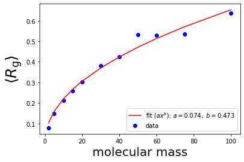

```
   a = 0.074181392537388896 ± 0.008560325675215728
   b = 0.472538147672860454 ± 0.028949346480283668
```

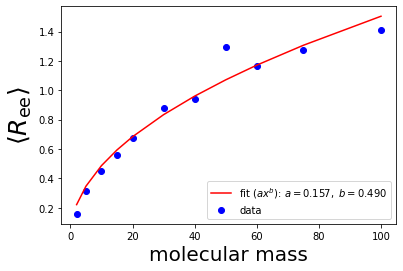

```
   a = 0.157481263318217629 ± 0.026733927323304710
   b = 0.490035528647239815 ± 0.042439704600986838
```

```python
plt.scatter(mm, Rg_ave_mean, label='data', color='blue')
popt, pcov = curve_fit(power, mm, Rg_ave_mean)
plt.plot(mm, power(mm, *popt), 'r-', label=r'fit $\left(ax^b\right)$: $a=%5.3f,~b=%.3f$' % tuple(popt))
plt.legend(loc=4)
plt.xlabel(r"molecular mass", fontsize=20)
plt.ylabel(r"$\left\langle{R_\mathrm{g}}\right\rangle$", fontsize=25)
#plt.savefig("plots/Rg_v_mm_scatter_fit.pdf", bbox_inches='tight')
plt.show()
print('   a =', '%0.18f' % popt[0], '±', "%.18f" % pcov[0,0]**0.5) #THE 2ND HALF IS CODE FOR CALCULATING FIT UNCERTAINTY
print('   b =', "%0.18f" % popt[1], '±', "%.18f" % pcov[1,1]**0.5)

plt.scatter(mm, Ree_ave_mean, label='data', color='blue')
popt, pcov = curve_fit(power, mm, Ree_ave_mean)
plt.plot(mm, power(mm, *popt), 'r-', label=r'fit $\left(ax^b\right)$: $a=%5.3f,~b=%.3f$' % tuple(popt))
plt.legend()
plt.xlabel(r"molecular mass", fontsize=20)
plt.ylabel(r"$\left\langle{R_\mathrm{ee}}\right\rangle$", fontsize=25)
#plt.savefig("plots/Ree_v_mm_scatter_fit.pdf", bbox_inches='tight')
plt.show()
print('   a =', '%0.18f' % popt[0], '±', "%.18f" % pcov[0,0]**0.5) #THE 2ND HALF IS CODE FOR CALCULATING FIT UNCERTAINTY
print('   b =', "%0.18f" % popt[1], '±', "%.18f" % pcov[1,1]**0.5)
```

#### Generating nice curves (no data)

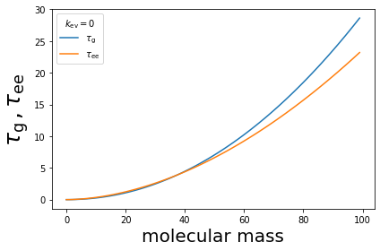

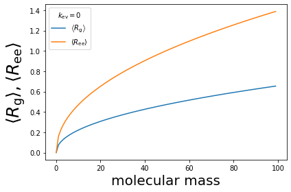

```python
χ = np.linspace(0,100, 100)
yg = power(χ, 0.002245738713339380, 2.052688245482727769)
yee = power(χ, 0.004914184456708002, 1.836929127175338516)

plt.plot(yg, label=r"$\tau_{\mathrm{g}}$")
plt.xlabel(r"molecular mass", fontsize=20)
#plt.ylabel(r"$\tau_{\mathrm{g}}$", fontsize=25)
#plt.legend()
plt.tight_layout()
#plt.savefig("plots/τg_v_mm_fit.pdf", bbox_inches='tight')
#plt.show()

plt.plot(yee, label=r"$\tau_{\mathrm{ee}}$")
#plt.xlabel(r"molecular mass", fontsize=20)
plt.ylabel(r"$\tau_{\mathrm{g}}\,,\tau_{\mathrm{ee}}$", fontsize=25)
plt.legend(title=r"$k_{\mathrm{ev}}=0$")
plt.tight_layout()
#plt.savefig("plots/τg-ee_v_mm_fit.pdf", bbox_inches='tight')
plt.show()


yg = power(χ, 0.074181392537388896, 0.472538147672860454)
yee = power(χ, 0.157481263318217629, 0.472538147672860454)

plt.plot(yg, label=r"$\left\langle{R_\mathrm{g}}\right\rangle$")
plt.xlabel(r"molecular mass", fontsize=20)
#plt.ylabel(r"$\left\langle{R_\mathrm{g}}\right\rangle$", fontsize=25)
plt.legend()
plt.tight_layout()
#plt.savefig("plots/Rg_v_mm_fit.pdf", bbox_inches='tight')
#plt.show()

plt.plot(yee, label=r"$\left\langle{R_\mathrm{ee}}\right\rangle$")
#plt.xlabel(r"molecular mass", fontsize=20)
plt.ylabel(r"$\left\langle{R_\mathrm{g}}\right\rangle,  \left\langle{R_\mathrm{ee}}\right\rangle$", fontsize=25)
plt.legend(title=r"$k_{\mathrm{ev}}=0$")
plt.tight_layout()
#plt.savefig("plots/Rg-ee_v_mm_fit.pdf", bbox_inches='tight')
plt.show()
```

#### Log-log plot

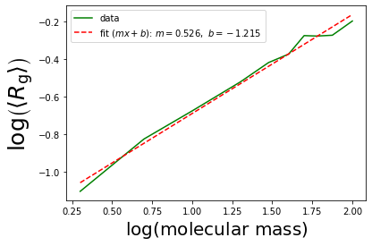

```python
def line(x, m, b):
    return m*x + b
plt.plot(np.log10(mm), np.log10(Rg_ave_mean), color='green', label='data')
plt.xlabel(r"$\log\left(\mathrm{molecular~mass}\right)$", fontsize=20)
plt.ylabel(r"$\log\left(\left\langle{R_\mathrm{g}}\right\rangle\right)$", fontsize=25)

popt, pcov = curve_fit(line, np.log10(mm), np.log10(Rg_ave_mean))
plt.plot(np.log10(mm), line(np.log10(mm), *popt), 'r--', label=r'fit $\left(mx+b\right)$: $m=%5.3f,~b=%.3f$' % tuple(popt))
plt.legend()
plt.savefig("plots/log_Rg_v_log_mm_dash_fit.pdf", bbox_inches='tight')
plt.show()
```

Professor Klotz: *Something to be aware of is that a logarithmic axis plot isn't the same as a plot of the logarithm.*

## Plotting the final configuration

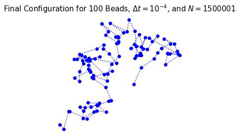

```python
arr = np.load(f'pos_data/data/k_ev=0/D_parameters/nbeads{nbeads}.npy')
N = len(arr[0])

final_x = []
final_y = []
for bead in arr:     # saving final positions of each bead in chain
    final_x.append(bead[N-1, 0])
    final_y.append(bead[N-1, 1])


plt.plot(final_x, final_y, 'bo:',); plt.grid()
plt.axis('scaled'); plt.axis(False)

plt.title(f"Final Configuration for {nbeads} Beads, " r"$\Delta t = 10^{-4}$," f" and $N = {N}$", size=15)

plt.tight_layout()
#plt.savefig(f'pos_data/pics/final_configuration{nbeads}.png', bbox_inches='tight')
plt.show()
```

## Recources

- [[1](https://www.eng.uc.edu/~beaucag/Classes/Physics/DynChapter6html/Chapter6.html)] The Rouse Model